# Machine Learning Prediction Assignment

Shutong Li

2018年5月20日

## Executive Summary

In this project, we use data from accelerometers on the belt, forearm, arm, and dumbell of 6 participants to predict the manner in which they did the exercise. This is the “classe” variable in the training dataset.

The training data are from:  
https://d396qusza40orc.cloudfront.net/predmachlearn/pml-training.csv  
The test data are from:  
https://d396qusza40orc.cloudfront.net/predmachlearn/pml-testing.csv

We’ll try three different prediction models: Random Forest, Decision Tree and Generalized Boosted Model. By comparing their accuracy, we choose Random Forest model as our prediction model, and apply the trained model to test dataset.

## Loading Data and Exploratory Data Analysis

At first, let’s download the training and test dataset.

```r
trainUrl <- "https://d396qusza40orc.cloudfront.net/predmachlearn/pml-training.csv"
testUrl  <- "https://d396qusza40orc.cloudfront.net/predmachlearn/pml-testing.csv"

trainData <- read.csv(trainUrl, na.strings=c("NA","#DIV/0!",""))
testData <- read.csv(testUrl, na.strings=c("NA","#DIV/0!",""))
```

After exploring the data, we found that some variables of trainData and testData have many NA values, and some factor variables can’t help to predict the exercise manner, like timestamp. So we need to cleanup the data first.

```r
# find NA data
sapply(trainData, function(x) sum(is.na(x)))
```

```
##                        X                user_name     raw_timestamp_part_1
##                        0                        0                        0
##     raw_timestamp_part_2           cvtd_timestamp               new_window
##                        0                        0                        0
##               num_window                roll_belt               pitch_belt
##                        0                        0                        0
##                 yaw_belt         total_accel_belt       kurtosis_roll_belt
##                        0                        0                    19226
##      kurtosis_picth_belt        kurtosis_yaw_belt       skewness_roll_belt
##                    19248                    19622                    19225
##     skewness_roll_belt.1        skewness_yaw_belt            max_roll_belt
##                    19248                    19622                    19216
##           max_picth_belt             max_yaw_belt            min_roll_belt
##                    19216                    19226                    19216
##           min_pitch_belt             min_yaw_belt      amplitude_roll_belt
##                    19216                    19226                    19216
##     amplitude_pitch_belt       amplitude_yaw_belt     var_total_accel_belt
##                    19216                    19226                    19216
##            avg_roll_belt         stddev_roll_belt            var_roll_belt
##                    19216                    19216                    19216
##           avg_pitch_belt        stddev_pitch_belt           var_pitch_belt
##                    19216                    19216                    19216
##             avg_yaw_belt          stddev_yaw_belt             var_yaw_belt
##                    19216                    19216                    19216
##             gyros_belt_x             gyros_belt_y             gyros_belt_z
##                        0                        0                        0
##             accel_belt_x             accel_belt_y             accel_belt_z
##                        0                        0                        0
##            magnet_belt_x            magnet_belt_y            magnet_belt_z
##                        0                        0                        0
##                 roll_arm                pitch_arm                  yaw_arm
##                        0                        0                        0
##          total_accel_arm            var_accel_arm             avg_roll_arm
##                        0                    19216                    19216
##          stddev_roll_arm             var_roll_arm            avg_pitch_arm
##                    19216                    19216                    19216
##         stddev_pitch_arm            var_pitch_arm              avg_yaw_arm
##                    19216                    19216                    19216
##           stddev_yaw_arm              var_yaw_arm              gyros_arm_x
##                    19216                    19216                        0
```

[output cut: 53 more lines]

```
##                    19300                        0                    19216
##         avg_roll_forearm      stddev_roll_forearm         var_roll_forearm
##                    19216                    19216                    19216
##        avg_pitch_forearm     stddev_pitch_forearm        var_pitch_forearm
##                    19216                    19216                    19216
##          avg_yaw_forearm       stddev_yaw_forearm          var_yaw_forearm
##                    19216                    19216                    19216
##          gyros_forearm_x          gyros_forearm_y          gyros_forearm_z
##                        0                        0                        0
##          accel_forearm_x          accel_forearm_y          accel_forearm_z
##                        0                        0                        0
##         magnet_forearm_x         magnet_forearm_y         magnet_forearm_z
##                        0                        0                        0
##                   classe
##                        0
```

```r
sapply(testData, function(x) sum(is.na(x)))
```

```
##                        X                user_name     raw_timestamp_part_1
##                        0                        0                        0
##     raw_timestamp_part_2           cvtd_timestamp               new_window
##                        0                        0                        0
##               num_window                roll_belt               pitch_belt
##                        0                        0                        0
##                 yaw_belt         total_accel_belt       kurtosis_roll_belt
##                        0                        0                       20
##      kurtosis_picth_belt        kurtosis_yaw_belt       skewness_roll_belt
##                       20                       20                       20
##     skewness_roll_belt.1        skewness_yaw_belt            max_roll_belt
##                       20                       20                       20
##           max_picth_belt             max_yaw_belt            min_roll_belt
##                       20                       20                       20
##           min_pitch_belt             min_yaw_belt      amplitude_roll_belt
##                       20                       20                       20
##     amplitude_pitch_belt       amplitude_yaw_belt     var_total_accel_belt
##                       20                       20                       20
##            avg_roll_belt         stddev_roll_belt            var_roll_belt
##                       20                       20                       20
##           avg_pitch_belt        stddev_pitch_belt           var_pitch_belt
##                       20                       20                       20
##             avg_yaw_belt          stddev_yaw_belt             var_yaw_belt
##                       20                       20                       20
##             gyros_belt_x             gyros_belt_y             gyros_belt_z
##                        0                        0                        0
##             accel_belt_x             accel_belt_y             accel_belt_z
##                        0                        0                        0
##            magnet_belt_x            magnet_belt_y            magnet_belt_z
##                        0                        0                        0
##                 roll_arm                pitch_arm                  yaw_arm
##                        0                        0                        0
##          total_accel_arm            var_accel_arm             avg_roll_arm
##                        0                       20                       20
##          stddev_roll_arm             var_roll_arm            avg_pitch_arm
##                       20                       20                       20
##         stddev_pitch_arm            var_pitch_arm              avg_yaw_arm
##                       20                       20                       20
##           stddev_yaw_arm              var_yaw_arm              gyros_arm_x
##                       20                       20                        0
```

[output cut: 53 more lines]

```
##                       20                        0                       20
##         avg_roll_forearm      stddev_roll_forearm         var_roll_forearm
##                       20                       20                       20
##        avg_pitch_forearm     stddev_pitch_forearm        var_pitch_forearm
##                       20                       20                       20
##          avg_yaw_forearm       stddev_yaw_forearm          var_yaw_forearm
##                       20                       20                       20
##          gyros_forearm_x          gyros_forearm_y          gyros_forearm_z
##                        0                        0                        0
##          accel_forearm_x          accel_forearm_y          accel_forearm_z
##                        0                        0                        0
##         magnet_forearm_x         magnet_forearm_y         magnet_forearm_z
##                        0                        0                        0
##               problem_id
##                        0
```

```r
# remove NA data from Train & Test data sets
trainDataFactors <- colnames(trainData)[colSums(is.na(trainData)) == 0]
testDataFactors <- colnames(testData)[colSums(is.na(testData)) == 0]

# remove NA data from testing set
allFactors <- union(trainDataFactors, testDataFactors)
trainData <- trainData[, names(trainData) %in% allFactors]
testData <- testData[, names(testData) %in% allFactors]

# remove variables which are useless for the prediction
trainData <- trainData[, -c(1:5)]
testData <- testData[, -c(1:5)]

# change a factor variable 'new_window' to integer class
trainData$new_window <- as.integer(trainData$new_window)
testData$new_window <- as.integer(testData$new_window)
```

## Create Data Partitions

```r
# create Training set and Validation set
library(caret)
inTrain  <- createDataPartition(y=trainData$classe, p=0.7, list=FALSE)
training <- trainData[inTrain, ]
testing  <- trainData[-inTrain, ]
dim(training)
```

```
## [1] 13737    55
```

```r
dim(testing)
```

```
## [1] 5885   55
```

```r
dim(testData)
```

```
## [1] 20 55
```

## Corrolation Analysis

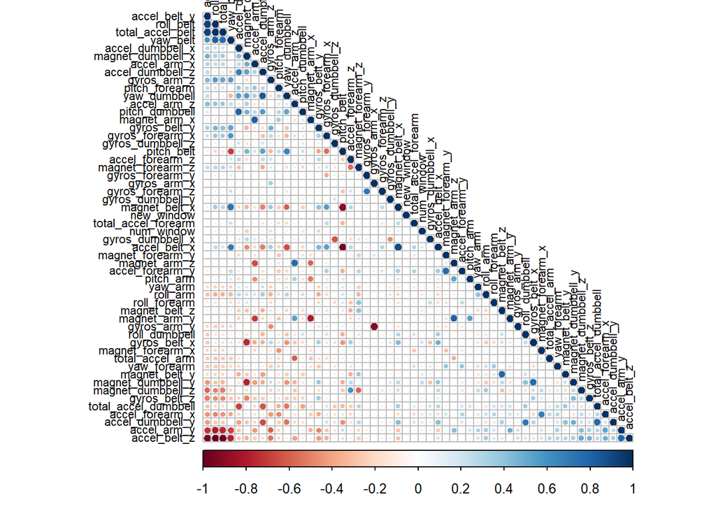

```r
library(corrplot)
corMatrix <- cor(training[, -55])
corrplot(corMatrix, order = "FPC", method = "circle", type = "lower", tl.cex = 0.7, tl.col = rgb(0, 0, 0))
```

Most of the variables are not corrolated, so we’ll not use PCA analysis, and we’ll use all variables to predict “classe”.

## Create Prediction Models

We’ll train 3 prediction models with ‘training’ partition, and then choose the best one which has the highest accuracy when applied to the ‘testing’ partition to predict 20 different test cases in testData. The 3 prediction models are: Random Forests, Decision Tree and Generalized Boosted Model. We’ll create Confusion Matrix for each model to compare their accuracies.

### Random Forests Model

```r
set.seed(503)
require(randomForest)
library(randomForest)
modFitRF <- randomForest(classe ~ ., data = training, method = "rf", importance = T,
                         trControl = trainControl(method = "cv", classProbs=TRUE, savePredictions=TRUE,
                                                  allowParallel=TRUE,  number = 10))
modFitRF
```

```
##
## Call:
##  randomForest(formula = classe ~ ., data = training, method = "rf",      importance = T, trControl = trainControl(method = "cv", classProbs = TRUE,          savePredictions = TRUE, allowParallel = TRUE, number = 10))
##                Type of random forest: classification
##                      Number of trees: 500
## No. of variables tried at each split: 7
##
##         OOB estimate of  error rate: 0.25%
## Confusion matrix:
##      A    B    C    D    E class.error
## A 3906    0    0    0    0 0.000000000
## B    4 2651    3    0    0 0.002633559
## C    0    8 2388    0    0 0.003338898
## D    0    0   15 2235    2 0.007548845
## E    0    0    0    3 2522 0.001188119
```

### Decision Tree Model

```r
set.seed(503)
modFitDT <- train(classe ~ ., data=training, method="rpart")
modFitDT$finalModel
```

```
## n= 13737
##
## node), split, n, loss, yval, (yprob)
##       * denotes terminal node
##
##  1) root 13737 9831 A (0.28 0.19 0.17 0.16 0.18)
##    2) roll_belt< 130.5 12587 8689 A (0.31 0.21 0.19 0.18 0.11)
##      4) pitch_forearm< -33.95 1148    6 A (0.99 0.0052 0 0 0) *
##      5) pitch_forearm>=-33.95 11439 8683 A (0.24 0.23 0.21 0.2 0.12)
##       10) num_window>=45.5 10947 8191 A (0.25 0.24 0.22 0.2 0.091)
##         20) magnet_dumbbell_y< 439.5 9367 6671 A (0.29 0.19 0.25 0.19 0.086)
##           40) roll_forearm< 124.5 5918 3495 A (0.41 0.19 0.19 0.16 0.045) *
##           41) roll_forearm>=124.5 3449 2251 C (0.079 0.19 0.35 0.23 0.16) *
##         21) magnet_dumbbell_y>=439.5 1580  715 B (0.038 0.55 0.048 0.25 0.12) *
##       11) num_window< 45.5 492  103 E (0 0 0 0.21 0.79) *
##    3) roll_belt>=130.5 1150    8 E (0.007 0 0 0 0.99) *
```

### Generalized Boosted Model

```r
set.seed(503)
trControlGBM <- trainControl(method = "cv", number = 5)
modFitGBM  <- train(classe ~ ., data=training, method = "gbm",
                    trControl = trControlGBM, verbose = FALSE)
modFitGBM$finalModel
```

```
## A gradient boosted model with multinomial loss function.
## 150 iterations were performed.
## There were 54 predictors of which 43 had non-zero influence.
```

## Confusion Matrixes

```r
predictRF <- predict(modFitRF, testing)
confusionMatrixRF <- confusionMatrix(predictRF, testing$classe)
confusionMatrixRF
```

```
## Confusion Matrix and Statistics
##
##           Reference
## Prediction    A    B    C    D    E
##          A 1673    2    0    0    0
##          B    0 1136    0    0    0
##          C    0    1 1026    7    0
##          D    0    0    0  956    0
##          E    1    0    0    1 1082
##
## Overall Statistics
##
##                Accuracy : 0.998
##                  95% CI : (0.9964, 0.9989)
##     No Information Rate : 0.2845
##     P-Value [Acc > NIR] : < 2.2e-16
##
##                   Kappa : 0.9974
##  Mcnemar's Test P-Value : NA
##
## Statistics by Class:
##
##                      Class: A Class: B Class: C Class: D Class: E
## Sensitivity            0.9994   0.9974   1.0000   0.9917   1.0000
## Specificity            0.9995   1.0000   0.9984   1.0000   0.9996
## Pos Pred Value         0.9988   1.0000   0.9923   1.0000   0.9982
## Neg Pred Value         0.9998   0.9994   1.0000   0.9984   1.0000
## Prevalence             0.2845   0.1935   0.1743   0.1638   0.1839
## Detection Rate         0.2843   0.1930   0.1743   0.1624   0.1839
## Detection Prevalence   0.2846   0.1930   0.1757   0.1624   0.1842
## Balanced Accuracy      0.9995   0.9987   0.9992   0.9959   0.9998
```

### Confusion Matix of Decision Tree Model

```r
predictDT <- predict(modFitDT, testing)
confusionMatrixDT <- confusionMatrix(predictDT, testing$classe)
confusionMatrixDT
```

```
## Confusion Matrix and Statistics
##
##           Reference
## Prediction    A    B    C    D    E
##          A 1519  452  471  406  103
##          B   21  421   32  179   85
##          C  128  266  523  336  221
##          D    0    0    0    0    0
##          E    6    0    0   43  673
##
## Overall Statistics
##
##                Accuracy : 0.5329
##                  95% CI : (0.52, 0.5457)
##     No Information Rate : 0.2845
##     P-Value [Acc > NIR] : < 2.2e-16
##
##                   Kappa : 0.3909
##  Mcnemar's Test P-Value : < 2.2e-16
##
## Statistics by Class:
##
##                      Class: A Class: B Class: C Class: D Class: E
## Sensitivity            0.9074  0.36962  0.50975   0.0000   0.6220
## Specificity            0.6599  0.93321  0.80428   1.0000   0.9898
## Pos Pred Value         0.5147  0.57046  0.35482      NaN   0.9321
## Neg Pred Value         0.9472  0.86050  0.88597   0.8362   0.9208
## Prevalence             0.2845  0.19354  0.17434   0.1638   0.1839
## Detection Rate         0.2581  0.07154  0.08887   0.0000   0.1144
## Detection Prevalence   0.5014  0.12540  0.25047   0.0000   0.1227
## Balanced Accuracy      0.7837  0.65141  0.65701   0.5000   0.8059
```

### Confusion Matix of Generalized Boosted Model

```r
predictGBM <- predict(modFitGBM, testing)
confusionMatrixGBM <- confusionMatrix(predictGBM, testing$classe)
confusionMatrixGBM
```

```
## Confusion Matrix and Statistics
##
##           Reference
## Prediction    A    B    C    D    E
##          A 1670   10    0    0    0
##          B    4 1107    7    1    4
##          C    0   21 1016    8    0
##          D    0    1    3  955    6
##          E    0    0    0    0 1072
##
## Overall Statistics
##
##                Accuracy : 0.989
##                  95% CI : (0.9859, 0.9915)
##     No Information Rate : 0.2845
##     P-Value [Acc > NIR] : < 2.2e-16
##
##                   Kappa : 0.986
##  Mcnemar's Test P-Value : NA
##
## Statistics by Class:
##
##                      Class: A Class: B Class: C Class: D Class: E
## Sensitivity            0.9976   0.9719   0.9903   0.9907   0.9908
## Specificity            0.9976   0.9966   0.9940   0.9980   1.0000
## Pos Pred Value         0.9940   0.9858   0.9722   0.9896   1.0000
## Neg Pred Value         0.9990   0.9933   0.9979   0.9982   0.9979
## Prevalence             0.2845   0.1935   0.1743   0.1638   0.1839
## Detection Rate         0.2838   0.1881   0.1726   0.1623   0.1822
## Detection Prevalence   0.2855   0.1908   0.1776   0.1640   0.1822
## Balanced Accuracy      0.9976   0.9843   0.9921   0.9943   0.9954
```

Clearly, Random Forest model and Generalized Boosted Model can achieve almost the same accuracy, but Random Forest has slightly higer accuracy. So we’ll apply Random Forest to Test Data.

## Applying the Random Forest Model to Test Data Set

```r
predictTEST <- predict(modFitRF, testData)
predictTEST
```

```
##  1  2  3  4  5  6  7  8  9 10 11 12 13 14 15 16 17 18 19 20
##  B  A  B  A  A  E  D  B  A  A  B  C  B  A  E  E  A  B  B  B
## Levels: A B C D E
```